# Population projection

20 February 2019

#### Introduction

We are now going to try different methods of predicting the future growth and of estimating the (long term) growth rate, $\lambda$ for the common frog.

First, you will need to install the package `popbio`:

In RStudio: `Tools/Install packages` …  
In R console: `install.packages("popbio")`

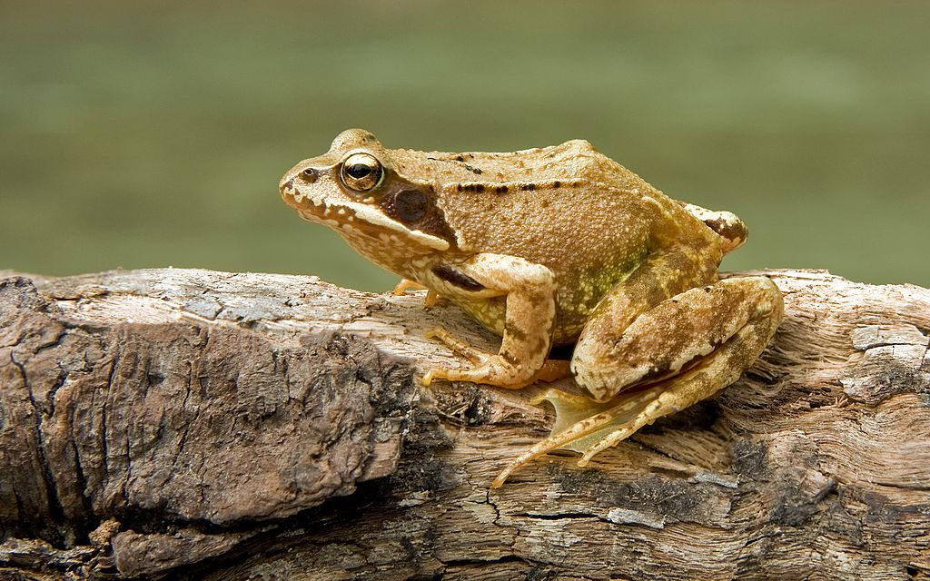

The equation we use to project a age/stage- or size structured population is:

$$\mathbf{n}(t+1) = \mathbf{An}(t)$$

**n** is a vector with *k* values (*k* is the number of classes in the demographic model),  
**A** is the projection matrix (Mills calls the projection or transition matrix **M**, you encounter both **A** and **M** frequently in the ecological literature).  
Note that the **bold** type font for **n** and **A** always indicates that we are dealing with vectors and matrices.

The projection matrix is a square matrix (equal number of rows and columns) of dimension *k* $\times$ *k*. A projection matrix must always have the same number of rows and columns as the number of classes in the demographic model!

The projection matrix **A** is multiplied with a vector **n**, which contains the number of individuals in each respective stage.

This is the projection matrix, **A**, for the common frog:

$$\mathbf{A} = \left[\begin{array}
{rrr}
0 & F_2 & F_3 \\
S_{21} & S_{22} & 0 \\
0 & S_{32} & S_{33} \\
\end{array}\right]
= \left[\begin{array}
{rrr}
0 & 52 & 279.5 \\
0.019 & 0.25 & 0 \\
0 & 0.08 & 0.43 \\
\end{array}\right]$$

(*F* for fecundity and *S* for probability of survival to the next year)

This species has three stages;

- Pre-juvenile (or first year, which involves egg, tadpole and over-wintering metamorph)
- Juvenile (next 2 years)
- Adult

And this is the population vector, **n**:

$$\mathbf{n} = \left[\begin{array}
{r}
70 \\
20 \\
10 \\
\end{array}\right]$$

When we multiply a matrix with a vector, the result is a vector with the same dimensions as the original vector (and not a single value). This particular example yields:

$$\mathbf{n}(t+1) = \left[\begin{array}
{rrrrrrrrrrr}
0.000 \times 70 + 52.0 \times 20 + 279.5 \times 10 \\
0.019 \times 70 + 0.25 \times 20 + 0.000 \times 10 \\
0.000 \times 70 + 0.08 \times 20 + 0.430 \times 10 \\
\end{array}\right]$$

Now, enter the projection matrix into R.

```r
#create an empty matrix and specify the dimensions (3 * 3)
#The arguments nrow and ncol defines the number of rows and columns.
A <-matrix(nrow=3, ncol=3)

#Add fecundity measures:
A[1,] <- c(0, 52, 279.5) #fill first row

A # inspect your matrix

#add survival probabilites:
A[2,] <- c(0.019, 0.25, 0) #fill second row
A[3,] <- c(0, 0.08, 0.43)  #fill third row

A # inspect your matrix
```

Create a vector with population sizes, `n`

```r
n0 <-c(70, 20, 10)

n0 #inspect the population vector
```

Matrix multiplication is carried out with the operator `%*%`:

```r
A %*% n0 # This gives us population size at time t+1
```

**Note**: Using the ordinary multiplication operator or changing the order of **A** and **n** will give different results. Make sure you use the operator `%*%` and that you right multiply **A** and **n**!

Make sure that you understand what the different values represent:

1. What is in the first row?
2. Which values are on the diagonal of the matrix?
3. What is the subdiagonal?

A matrix element is usually denoted by a, and the subscripts are usually <sub>i</sub> for row and <sub>j</sub> for column. Thus, the matrix element for adult survival, 0.43, is referenced as a<sub>33</sub>.

Next, simulate how this population changes over time in a stable environment according to the equation **n**(t+1) = **An**(t).

```r
n1 <- A %*% n0  # This gives n(t=1)
n1                    # Print n to screen
n2 <- A %*% n1      # Repeat the multiplication, this gives n(t=2)
# note that this will overwrite the original vector n

n2
sum(n2)     # To get total number of individuals

# To view the proportional distribution among classes:
n2/sum(n2)
```

Now, we will **predict the future growth** of this population and **estimate the (long term) growth rate $\lambda$** by calculating $\lambda$ for each time step.

At some point $\lambda$ and the proportion of individuals in each life-stage will stabilize. This is called the **stable stage distribution**. Will find out how long it takes to reach the stable stage distribution. (We will consider $\lambda$ stable when the first four decimal places have stabilised (i.e. are unchanged among iterations)).

We can do this by repeating the commands given above over and over but it’s more efficient to create a for-loop that that does the calculations automatically. Let’s project the population 30 years into the future:

```r
#specify the number of years that we want to project into the future (the number of iterations).
years <- 30

#Set up an empty matrix to hold the calculations (called e.g. `N`) where rows are years and columns are classes. For each time step, we'll send the results from the matrix-population vector multiplication to the corresponding row in the result matrix N.

N <- matrix (nrow=years+1, ncol=ncol(A))

#We have to add an extra row (years +1) for the initial year.

# Send initial pop size vector to first row in matrix N
N[1,] <- n0

#Build a for-loop for repeated matrix multiplication
#repeat population projection for 'years' number of time steps:

for (t in 1:years) { N[t+1,] = A %*% N[t,] }

#Notice how the code resembles the basic projection equation n(t+1) = An(t)
```

We have projected the population sizes for each life-stage. To determine when the stable stage distribution is reached we need to calculate lambda and to calculate lambda we need the total population size for each time step.

```r
totN <- rowSums(N) #total population size for each time step
```

Calculate $\lambda$ for each time step ($\lambda = N_{t+1}/N_t$):

```r
Lambdas = totN[2:31] / totN[1:30]
```

To find out what the stable stage distribution looks like, calculate the proportion of individuals in each class for each time step:

```r
propN = N/totN
```

Let’s tie our calculations togehter in a table:

```r
table1 <- cbind(1:years, propN[2:31,], totN[2:31], Lambdas)
colnames(table1) = c("year", "prop pre-\njuveniles", "prop \njuveniles",
                     "prop adults", "total N", "lambda")
knitr::kable(table1, digits = 4) #requires installation of package 'knitr'
```

- How long does it take to reach the stable stage distribution?
- What is the stable stage distribution (what proportion of the population are in the three different life-stages)?
- What will be the size of the population in 20 years?

Plot change in lambda over time for each time step t

```r
#Plot Change in lambda over time for each time t
#(note years-1, since the number of time steps is t-1!).
plot(0:(years-1), Lambdas, xlab="Time(t)", ylab=expression(lambda), las=1, type="b", ylim=c(0.5, 1.5))

#ylim is used to adjust y-limits for visibility
```

**Plot total population size over time**, as well as the number of individuals in each class over time:

```r
# Plot each class as a separate line on natural scale
matplot(0:years, N, xlab="Time (t)", ylab="Population size", font.lab=2,type="l",lwd=2)
```

Now that you’ve done all this hard work it’s time for me to tell you that we can derive growth rate $\lambda$, stable stage distribution and reproductive values directly from the matrix, without doing the projection (the `for-loop`). This is because $\lambda$, stable stage distribution and reproductive values are all mathematical properties of the transition matrix (Caswell 2001). - **The dominant eigenvalue equals $\lambda$**, the long-term population growth rate  
- **The right eigenvector (w)** of the dominant eigenvalue is a vector that provides the stable stage distribution.  
- **The left eigenvector (v)** of the dominant eigenvalue is a vector that provides reproductive values.

We can do a so called `eigen analysis` using the `popbio` package:

```r
library(popbio) #Load package
eigen.analysis(A)
```

or just extract the parameters that we’re after directly:

```r
lambda(A)
stable.stage(A)
reproductive.value(A)
```

Compare lambda with your results from the iterations. Are they the same?

It is important to remember that lambda and the stable stage distribution give the expected, long-term (asymptotic) dynamics of the system. However, a population can show very different (short-term) dynamics depending on the distribution of individuals in the initial start vector at t=0.

Projection can be done with the `pop.projection function`, a very useful function. Try this and interpret the output (you will probably recognise the results from your own calculations!):

```r
N <-pop.projection(A=A, n=n0, iterations=30)
N
```

##### References

Caswell, H. 2001. Matrix Population Models: Construction, Analysis, and Interpretation. 2nd edition. Sinauer Associates, Sunderland, MA.

Mills, L. S. 2013. Conservation of Wildlife Populations. Demography, Genetics, and Management. 2nd edition. John Wiley & Sons, Chichester, West Sussex, UK.

Morris, W. F., and D. F. Doak. 2002. Quantitative Conservation Biology: Theory and Practice of Population Viability Analysis. Sinauer Associates, Sunderland, MA.

Stevens, M. H. H. 2009. A Primer of Ecology with R. Springer Science, New York.